# Administrative School Closures Descriptive Report

Author

Mateo Frumholtz

Published

November 9, 2024

# Number of Schools in the Twin Cities Metro

**School Level Imputations**

There is missing school level data (i.e. high school, middle school, elementary school) for records before 2000. We imputed pre-2000 school levels based on the level that was assigned most often to that school after 2000. It’s uncommon, but some schools change levels over time. We standardized all school levels to be consistent across time. This may create some inaccuracies in any school level analysis or stratification.

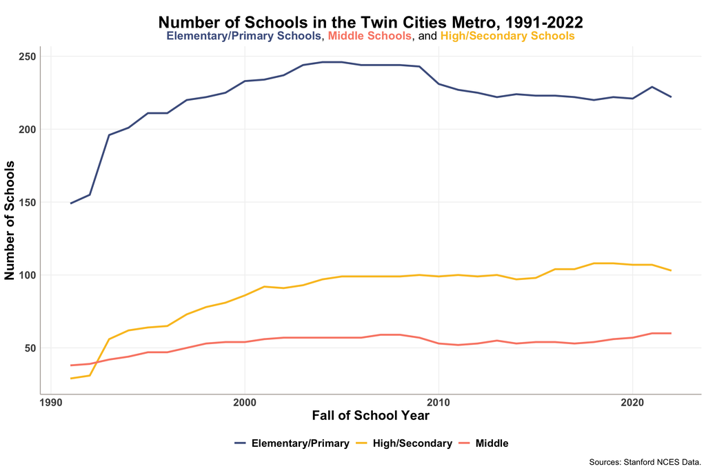

# Number of Administrative School Closures and Openings Over Time

**Limitations**

A school closure was defined as any school that had students for at least one year after 2001 followed by no students in a subsequent year. A school opening is defined as a school that had no students in 2001 but enrolled students before 2022 for at least one year. Some schools reopen after being closed, and only their initial closure is reflected in this analysis. The definition of closures used for this analysis most likely identifies what would be called **administrative closures**, whereby a school might close temporarily while it undergoes construction or district reshuffling. Finally, schools with more than 100 students at time of opening or closure were selected for this analysis. (See Supplemental Materials for an a map of all Twin Cities Metro school status by year.)

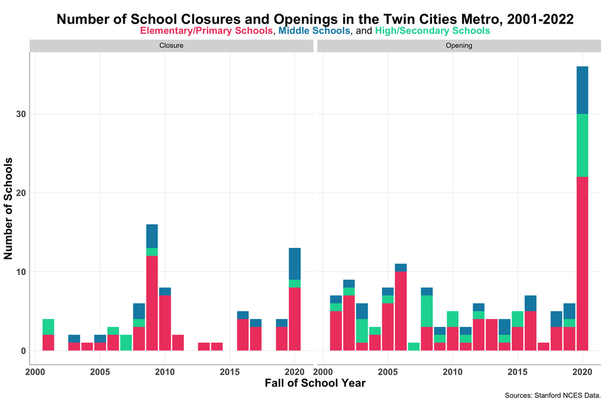

## What school districts expereinced the most administrative closures?

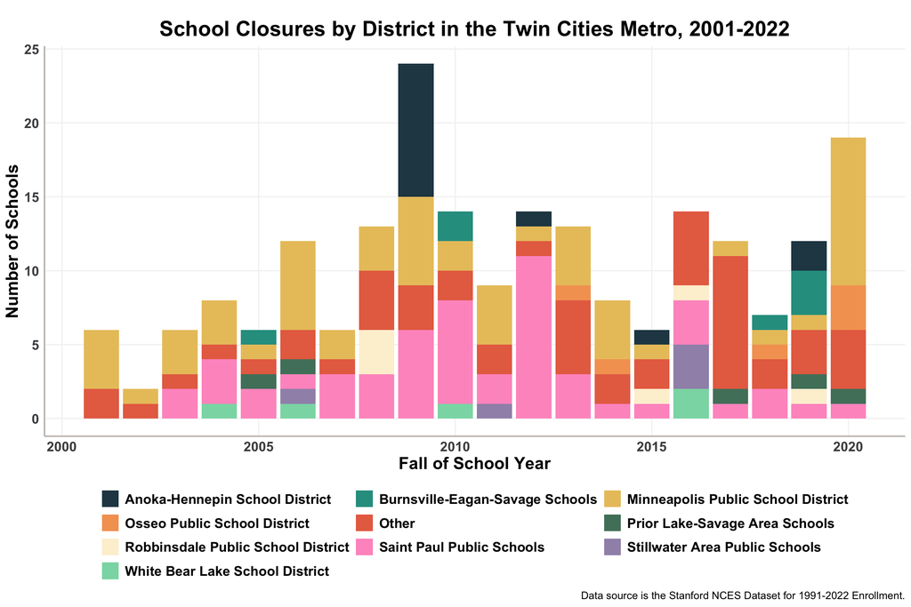

Figure 1: School Closures by District in the Twin Cities Metro, 2001-2022

## Among schools that experienced administrative closures, what racial groups are most impacted over time?

**Limitations**

Any estimates of counts of people affected by school closures will impacted by the limitations of estimating school closures themselves. The figures below estimate the impact of school closures on students across the metro.

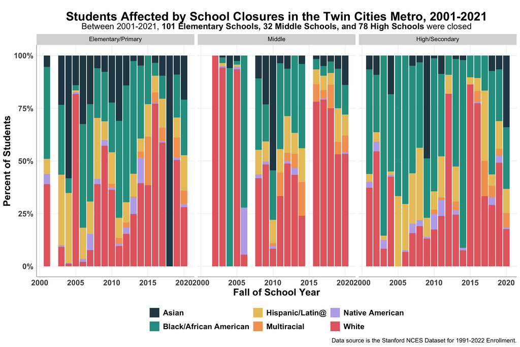

## Within districts, are schools that closed more likely to have students of color and on free or reduced lunch programs?

**Analysis Description**

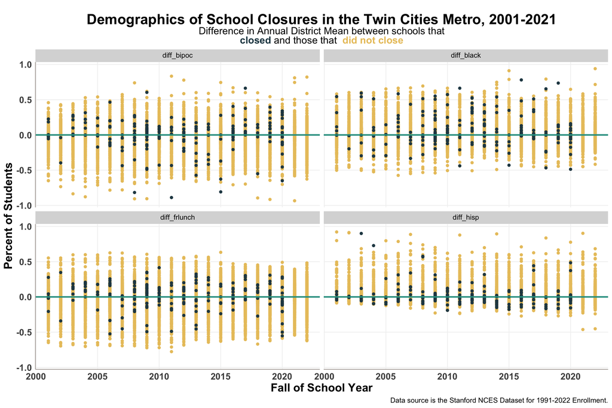